# 7 Statistiques Descriptives Univariées

- Montrer tout le code
- Cacher tout le code

Auteur

Affiliation

Daniel Coulombe

Institut des Sciences, Technologies et Études Avancées d’Haïti (ISTEAH)

Date

29/03/2024

## 7.1 Objectifs d’apprentissage

À la fin de l’étude de ce chapitre, vous devriez être en mesure de:

- pour chacun des types de données (qualitatives et quantitatives):
  - Générer des ensembles de données aléatoires
  - Produire des graphiques appropriés
  - Obtenir les indices de tendance centrale appropriés
  - Obtenir les indices de dispersion appropriés
  - Décrire la forme de la distribution, qualitativement et numériquement

## 7.2 Introduction

Dans le chapitre 2, nous avons rencontré des distributions de probabilités permettant de résumer le ‘comportement’ d’une variable donnée en indiquant pour chacune des valeurs possibles, la probabilité d’occurrence.

Dans un contexte de recherche, on obtient des observations pour plusieurs variables et il est d’usage, dans un premier temps suivant la collecte des données, d’étudier les principales caractéristiques de l’ensemble des informations recueillies. Cet exercice peut n’impliquer qu’une variable à la fois (analyse univariée), des paires de variables (analyse bivariée), ou un certain nombre de variables (analyse multivariée). Dans cette section, nous présenterons les différents indices permettant de quantifier ces caractéristiques.

On peut classifier les données statistiques en deux grandes catégories:

- Les données qualitatives: données indiquant l’appartenance à l’une ou l’autre d’un ensemble de catégories, que ces catégories soient ordonnées (données ordinales), ou non (données nominales). Par exemple, un individu peut occuper un emploi clérical plutôt que manuel (nominal), et sa performance au travail se situe au troisième rang dans une équipe de 20 employée (ordinal).
- Les données quantitatives: données indiquant le degré ou l’importance d’une caractéristique particulière. Par exemple, un individu obtient un score de 70.2 à l’échelle de dépression de Beck (donnée d’intervalle), et sa taille est de 1,83 mètre (échelle de rapport).

Pour chacun des types de données, il existe des indices permettant de quantifier les principales caractéristiques d’une distribution. Ce sont ces indices qui seront présentés ici.

## 7.3 Données qualitatives

Les données qualitatives peuvent prendre l’une ou l’autre de deux formes: nominales et ordinales. Dans le premier cas, les attributs de la variable sont des catégories mutuellement exclusives entre lesquelles aucun ordre n’existe. Tous les arrangements des différents attributs (différentes catégories) sont parfaitement équivalents. La seule opération qu’il est possible d’effectuer sur ce type de données est la comptabilisation des effectifs pour chacune des catégories.

Dans le second cas, la variable possède différents attributs, comme pour les variables nominales, mais ces attributs sont ordonnés: un attribut a quelque chose de plus que le précédent, et quelque chose de moins que le suivant. Par contre, la distance qui sépare ces attributs n’est pas spécifiée. La seule information dont on dispose est qu’une donnée est plus grande ou plus petite qu’une autre.

Ces deux types de données sont fréquents dans la littérature scientifique. Dans les paragraphes suivants, nous examinons diverses méthodes permettant d’en fournir une description.

### 7.3.1 Données nominales: Génération

Dans un contexte de recherche, les données qualitatives (échelle nominale ou ordinale) sont très fréquentes. Leur examen est plus simple que dans le cas de données quantitatives, mais l’intérêt de cet examen demeure.

La génération de données nominales aléatoires est simple. Il suffit de définir les catégories de cette variable, de spécifier les probabilités d’occurrence de chacune d’elles, et d’utiliser la fonction **sample()** pour effectuer le travail. Supposons un ensemble de 500 observations nominales réparties en 5 catégories nommées A, B, C, D et E, dont les probabilités d’occurrence sont respectivement 0.3, 0.1, 0.2, 0.15 et 0.25. La commande suivante est tout ce dont nous avons besoin pour accomplir cette tâche:

```r
x = sample(LETTERS[1:5],
           500,
           replace=TRUE,
           prob=c(.3,.1,.2,.15,.25))
head(x,10)
```

```
#>  [1] "B" "E" "E" "D" "E" "C" "A" "B" "C" "A"
```

La fonction **sample()** possède toute la fonctionnalité permettant de générer des données tant qualitatives que quantitatives, et nous l’utiliserons abondamment dans les discussions futures. Pour des données nominales, il suffit de dresser une liste exhaustive des catégories utilisées, et d’en sélectionner le nombre nécessaire, **avec remise** (*replace=TRUE*). On peut également indiquer les probabilités d’occurrence (ou fréquence relative) de chaque catégorie à l’aide d’un vecteur approprié. Par exemple, générons des données concernant le niveau d’éducation observé pour un ensemble de 20 sujets:

```r
# Liste des niveaux
EdLev <- c("Aucune", "Maternelle","Fondam1", "Fondam2",
           "Lycee", "Bac","Maitrise", "Doctorat")

# Probabilités associées au niveau d'éducation
pr <- c(0.013, 0.05, 0.261, 0.246, 0.165, 0.064, 0.09, 0.075)

ed <- sample(EdLev, 20, replace=TRUE, prob = pr)
ed
```

```
#>  [1] "Lycee"    "Maitrise" "Fondam2"  "Fondam1"  "Fondam2"  "Doctorat"
#>  [7] "Bac"      "Fondam2"  "Fondam2"  "Lycee"    "Lycee"    "Fondam2"
#> [13] "Bac"      "Fondam1"  "Bac"      "Fondam1"  "Maitrise" "Doctorat"
#> [19] "Fondam2"  "Fondam2"
```

Il en va de même pour le statut marital, en supposant l’équiprobabilité des différentes catégories:

```r
marital <- c("Marié", "Divorcé", "Veuf", "Séparé", "Célibataire")
mar = sample(marital, 20, replace=TRUE)
mar
```

```
#>  [1] "Célibataire" "Marié"       "Séparé"      "Veuf"        "Divorcé"
#>  [6] "Veuf"        "Divorcé"     "Séparé"      "Séparé"      "Célibataire"
#> [11] "Marié"       "Divorcé"     "Séparé"      "Célibataire" "Marié"
#> [16] "Séparé"      "Veuf"        "Marié"       "Veuf"        "Célibataire"
```

La librairie **wakefield** offre des simulateurs de données pour près de 100 types de variables distincts. On en trouvera la liste en cliquant [ICI](https://rdrr.io/cran/wakefield/man/). Cependant, il est souvent plus simple d’utiliser la fonction **sample()** comme nous l’avons fait ci-dessus.

### 7.3.2 Données nominales: Tableau et représentation graphique

Afin de résumer un ensemble de données nominales, la production d’un tableau affichant les effectifs de chaque catégorie est de mise. Sous R, on peut utiliser la fonction **table()** à cette fin:

```r
tbl.ed <- table(ed)
tbl.ed
```

```
#> ed
#>      Bac Doctorat  Fondam1  Fondam2    Lycee Maitrise
#>        3        2        3        7        3        2
```

```r
tbl.mar <- table(mar)
tbl.mar
```

```
#> mar
#> Célibataire     Divorcé       Marié      Séparé        Veuf
#>           4           3           4           5           4
```

Par la suite, on peut donner une forme plus efficace au tableau obtenu, pour les besoins de communication:

Répartition du Niveau d'éducation

| ed | Freq |
| --- | --- |
| Bac | 3 |
| Doctorat | 2 |
| Fondam1 | 3 |
| Fondam2 | 7 |
| Lycee | 3 |
| Maitrise | 2 |

Répartition du Statut Marital

| mar | Freq |
| --- | --- |
| Célibataire | 4 |
| Divorcé | 3 |
| Marié | 4 |
| Séparé | 5 |
| Veuf | 4 |

Un diagramme en barres est une représentation graphique appropriée dans le cas d’une variable nominale. La fonction **barplot()** permet la production d’un tel diagramme:

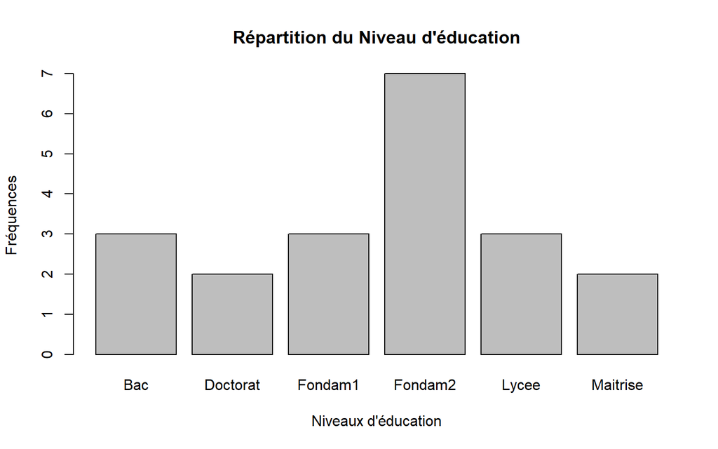

Diagramme en barres représentant la distribution du Niveau déducation. Les fréquences sont représentées par la hauteur des barres.

```r
barplot(tbl.ed,
        main="Répartition du Niveau d'éducation",
        xlab="Niveaux d'éducation",
        ylab="Fréquences")
```

De manière alternative, un diagramme en secteurs peut représenter ce type de données.

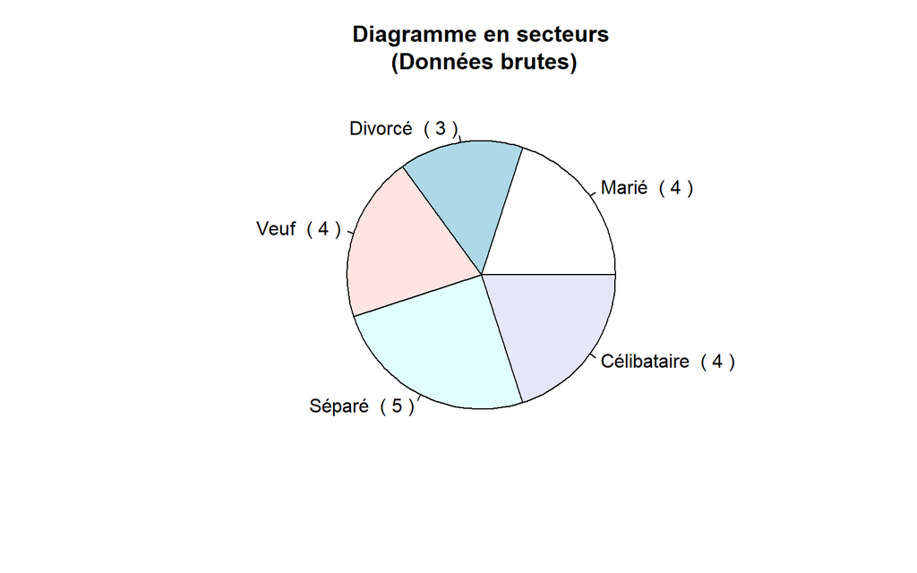

Diagramme en secteurs représentant la distribution du Statut Marital

```r
lbls <- marital
pie(tbl.mar,
    labels = paste(lbls," (",tbl.mar,")"),
    main="Diagramme en secteurs\n (Données brutes)")
```

Pour ce type de graphique, par contre, on a souvent avantage à utiliser les proportions ou les pourcentages occupés par chaque secteur, plutôt que les fréquences absolues:

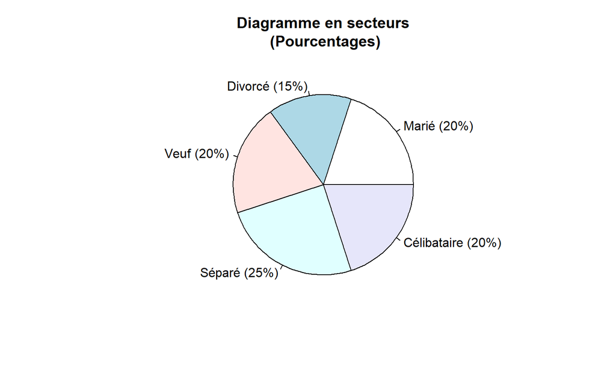

Diagramme en secteurs représentant la distribution du Statut Marital, en pourcentage. Les proportions sont proportionnelles à l’angle des secteurs.

```r
lbls <- marital
pct <- round(tbl.mar/sum(tbl.mar)*100)
lbls <- paste(lbls," (", pct,"%)",sep="")
pie(tbl.mar,
    labels = lbls,
    main="Diagramme en secteurs\n (Pourcentages)")
```

### 7.3.3 Données nominales: Tendance centrale

Dans le cas de données nominales, la seule mesure de tendance centrale qu’il est possible d’utiliser est le **mode**. Il s’agit simplement de la catégorie dont l’effectif est le plus élevé. On parlera alors de **catégorie modale**. L’examen du tableau de fréquence en permet la détermination rapide.

La fonction suivante permet de déterminer le mode d’un ensemble de données nominales:

```r
ModeCat = function(x) {
   uniqx <- unique(x)
   m = uniqx[which.max(tabulate(match(x, uniqx)))]
   fm = sum(x==m)
   return(c(m,fm))
}
```

Cette fonction retourne un vecteur composé de deux items: la catégorie et la fréquence modale. Par exemple:

```r
x <- round(sample(1:10,200,replace=TRUE))
mo <- ModeCat(x)
table(x)
```

```
#> x
#>  1  2  3  4  5  6  7  8  9 10
#> 11 17 25 17 29 24 28 18 14 17
```

```r
cat("Catégorie modale = ",mo[1])
```

```
#> Catégorie modale =  5
```

```r
cat("Fréquence Modale = ",mo[2])
```

```
#> Fréquence Modale =  29
```

Il arrive parfois que la répartition d’un ensemble de données nominales présente plus qu’un mode. Dans un tel cas, une description des données ne peut omettre la détermination de l’ensemble des modes. Certaines fonctions nous permettent d’examiner ces situations. Par exemple, la fonction **Mode()**, de la librairie **DescTools** pourrait s’avérer utile dans un tel cas.

Supposons une variable nominale comportant 7 catégories, numérotées de 1 à 7. Supposons également que la répartition des données est unimodale. Le code R suivant permet de générer une telle variable, pour un total de N = 50 observations. Par la suite, on peut établir la répartition des données:

```r
x <- sample(1:7, 50,
            replace = TRUE,
            prob = c(1, 2, 3, 4, 3, 2, 1))
table(x)
```

```
#> x
#>  1  2  3  4  5  6  7
#>  3 14 10 10  8  3  2
```

De cette répartion, il est facile de distinguer le mode, qui correspond au score le plus fréquent. On peut obtenir cet indice à l’aide de la fonction **Mode()** de la librairie **DescTools**:

```r
modeX <- DescTools::Mode(x)
```

```
#> Catégorie(s) Modale(s) =  2
```

```
#> La distribution est  Unimodale
```

```
#> Fréquence(s) Modales(s) =  14
```

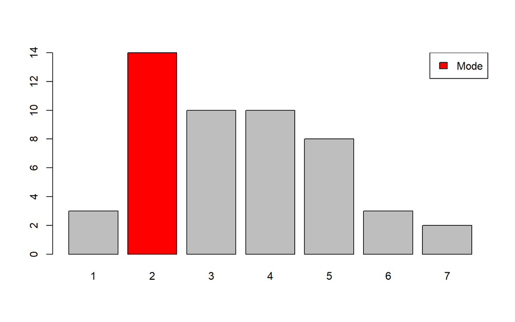

Figure 7.1: Diagramme en barres illustrant la catégorie modale, indiquée en rouge.

```r
tbl <- table(x)
# Représentation graphique
clrs <- c(rep("grey", 7))
clrs[modeX] <- "red"
barplot(tbl, col = clrs)
legend("topright", "Mode", fill = "red")
```

Une répartition sera bimodale, ou multimodale, si l’effectif le plus élevé apparait dans 2+ catégories. Par exemple:

```r
x <- c(rep(1, 2), rep(2, 8), rep(3, 3),
       rep(4, 4), rep(5, 8), rep(6, 2), rep(7, 5))
tbl <- table(x)
tbl
```

```
#> x
#> 1 2 3 4 5 6 7
#> 2 8 3 4 8 2 5
```

```r
mode <- DescTools::Mode(x)
distmode <- c("Uniforme (sans mode)",
              "Unimodale",
              "Bimodale",
              "Multimodale")
if (is.na(mode[1])) {
    nomode <- 1
} else if (length(mode) > 2) {
    nomode <- 4
} else {nomode <- length(mode)+1}
cat("Catégorie(s) Modale(s) = ", mode)
```

```
#> Catégorie(s) Modale(s) =  2 5
```

```r
cat("La distribution est ",distmode[nomode])
```

```
#> La distribution est  Bimodale
```

```r
if(!is.na(mode[1])){
  cat("Fréquence(s) Modales(s) = ", as.integer(attributes(mode)))}
```

```
#> Fréquence(s) Modales(s) =  8
```

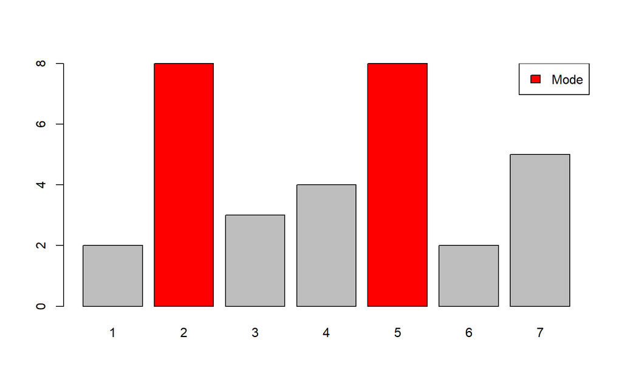

```r
# Représentation graphique
clrs <- c(rep("grey", 7))
clrs[mode] <- "red"
barplot(tbl, col = clrs)
legend("topright", "Mode", fill = "red")
```

La fonction **Mode()** utilisée ci-dessus permet donc de mettre en évidence la présence de plusieurs modes dans une distribution. Par contre, ne seront considérées comme modes uniquement les valeurs dont les fréquences sont identiques, comme c’était le cas dans le dernier exemple. En pratique, une distribution telle que la suivante serait très probablement considérée comme **bimodale**, même si les fréquences modales ne sont pas identiques. :

```
#> x
#>  1  2  3  4  5  6  7
#>  2  8  3  4 10  2  4
```

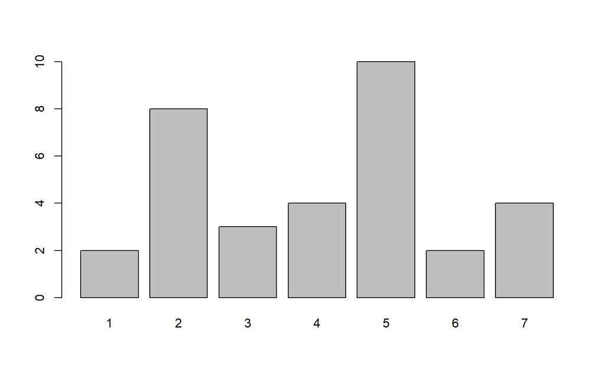

La fonction **modes()**, de la librairie **agrmt** déterminera l’existence de catégories modales dont les fréquences diffèrent. L’argument **tolerance** permet d’ajuster le degré de ‘ressemblance’ à partir duquel on considère que les fréquences sont égales. Pour les données que nous venons de générer,supposant qu’on considère qu’une différence de 2 unités n’est pas suffisamment grande pour qu’elles soient jugées différentes (tolerance=2), on obtient:

```r
md <- agrmt::modes(tbl,tolerance=2)
md
```

```
#> $at
#> [1] 1 2 3 4 5 6 7
#>
#> $frequencies
#> x
#>  1  2  3  4  5  6  7
#>  2  8  3  4 10  2  4
#>
#> $mode
#> [1] 2 5
#>
#> $positions
#> [1] 2 5
#>
#> $contiguous
#> [1] FALSE
```

```r
cat("Fréquence(s) Modale(s) = ",tbl[md$mode])
```

```
#> Fréquence(s) Modale(s) =  8 10
```

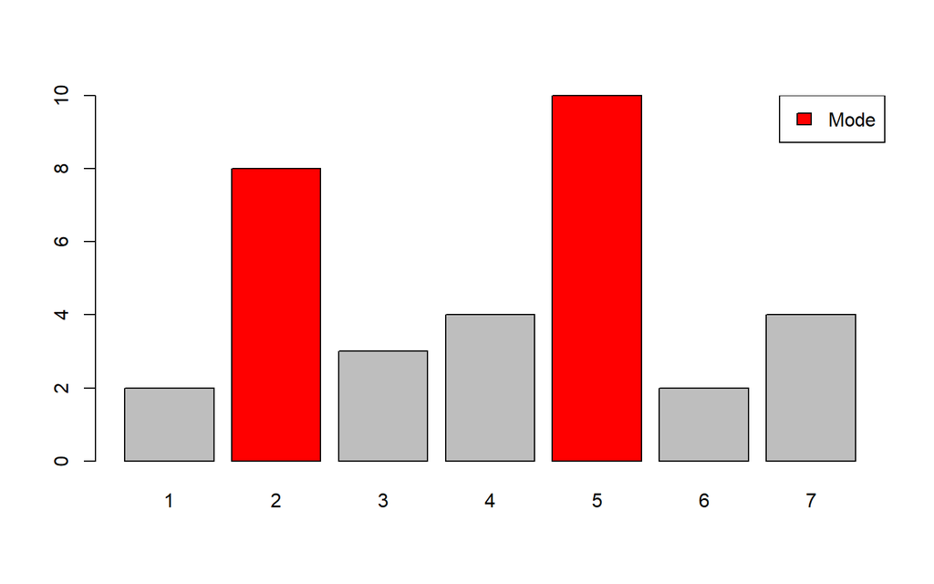

Figure 7.2: Diagramme en barres illustrant la présence de deux modes dont les fréquences modales sont inégales.

On détecte 2 modes, respectivement aux positions 2 et 5, et ces modes ne sont pas adjacents. Les fréquences modales sont respectivement 8 et 10.

Finalement, la fonction **secondModes()**, toujours de la librairie **agrmt**, permet de mettre en évidence les deux principaux modes. Pour l’exemple précédent, on a:

```r
md <- secondModes(tbl)
paste("Premier mode: Catégorie ",md$positions[[1]])
```

```
#> [1] "Premier mode: Catégorie  5"
```

```r
paste("Second  mode: Catégorie ",md$positions[[2]])
```

```
#> [1] "Second  mode: Catégorie  2"
```

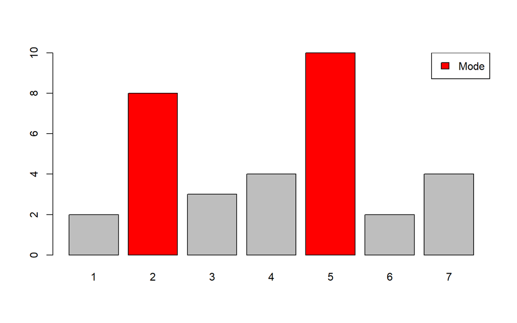

Figure 7.3: Diagramme en barres représentant une distribution bimodale (fréquences inégales).

```r
clrs  <- c(rep("grey",7))
clrs[md$positions[[1]]]  <-  "red"
clrs[md$positions[[2]]]  <-  "red"
barplot(tbl, col = clrs)
legend("topright", "Mode", fill = "red")
```

#### 7.3.3.1 Exercice 1

1. Chargez la librairie **wakefield**:

```r
library(wakefield)
```

2. Utilisez la fonction **employment()** pour générer le statut d’emploi de 500 personnes. Les proportions pour chaque catégories sont estimées à 50%, 15%, 10%, 15% et 10%, respectivement. La variable qui sera générée portera le nom: EMPLOI. Éditez le code R ci-dessous pour obtenir ce résultat

```r
n  <-  500
x  <-  employment(n,x = c("Plein Temps", "Temps Partiel",
                          "Sans Emploi", "Retrait", "Étude"),
                  prob = c(0.6, 0.1, 0.1, 0.1, 0.1),
                  name = "Variable")
```

3. Obtenez un diagramme en barres pour représenter ces données. Notez que vous devez obtenir le tableau de fréquences au préalable.
4. Construisez un diagramme en secteur pour représenter les proportions des différents statuts d’emploi.
5. Déterminez le mode de cette distribution, en utilisant la fonction **Mode()** de la librairie **DescTools**. Dans ce cas, le mode est déterminé à partir des données originales (**x**). Puis, refaites le travail en utilisant la fonction **modes()** de la librairie **agrmt**. Dans ce cas, le mode est calculé à partir du tableau de fréquences.

### 7.3.4 Données **ordinales**: Génération et tendance centrale

Dans le cas de données ordinales, la tendance centrale peut être évaluée à l’aide du mode, tel que défini dans la section précédente, ou en obtenant la médiane, qui est située exactement au centre de la séquence ordonnée des scores. Elle correspond à la donnée au-dessous de laquelle on retrouve 50% de la distribution. Elle coupe la distribution en deux parties égales.

Sous R, la fonction **median()** retourne la médiane du vecteur correspondant à son argument. Le code R suivant permettra d’illustrer la procédure. La fonction **r_sample_ordered()** de la librairie **wakefield** permet de générer des données ordinales: un ensemble de réponses à un item de type Likert (1 = Tout-à-fait pour, … , 7 = Tout-à-fait contre). On obtient ensuite la médiane, après s’être assuré que les données sont perçues comme étant numériques par la fonction median()::

```r
library(wakefield)
ord  <-  r_sample_ordered(n=50, c(1:7),
                          prob = NULL,
                          name = "Réponse")
head(ord,10)
```

```
#>  [1] 5 4 6 2 3 5 1 2 7 6
#> Levels: 7 < 6 < 5 < 4 < 3 < 2 < 1
```

```r
ord  <-  as.numeric(ord)
cat("La médiane est égale à ",median(ord))
```

```
#> La médiane est égale à  4.5
```

Rappelons que la médiane n’a de sens que pour les données dont le niveau de mesure est ordinal ou supérieur (d’intervalle ou de rapport).

La médiane correspond au second quartile de la distribution: le score sous lequel on retrouve 50% de la distribution. Le premier et le troisième quartile sont les scores sous lesquels on retrouve 25% et 75% de la distribution, respectivement. Sous R, on peut obtenir ces valeurs à l’aide de la fonction **quantile()**. Les arguments sont d’abord la variable à étudier, et la ou les proportions se trouvant sous le ou les scores recherchés:

```r
quantile(ord,c(0.25,0.5,0.75))
```

```
#> 25% 50% 75%
#> 2.0 4.5 6.0
```

De manière alternative, la fonction **summary** retourne tant les quartiles que le minimum et le maximum d’une ensemble de données:

```r
summary(ord)
```

```
#>    Min. 1st Qu.  Median    Mean 3rd Qu.    Max.
#>    1.00    2.00    4.50    4.26    6.00    7.00
```

Ces différents indices sont les ingrédients d’un diagramme en boîte:

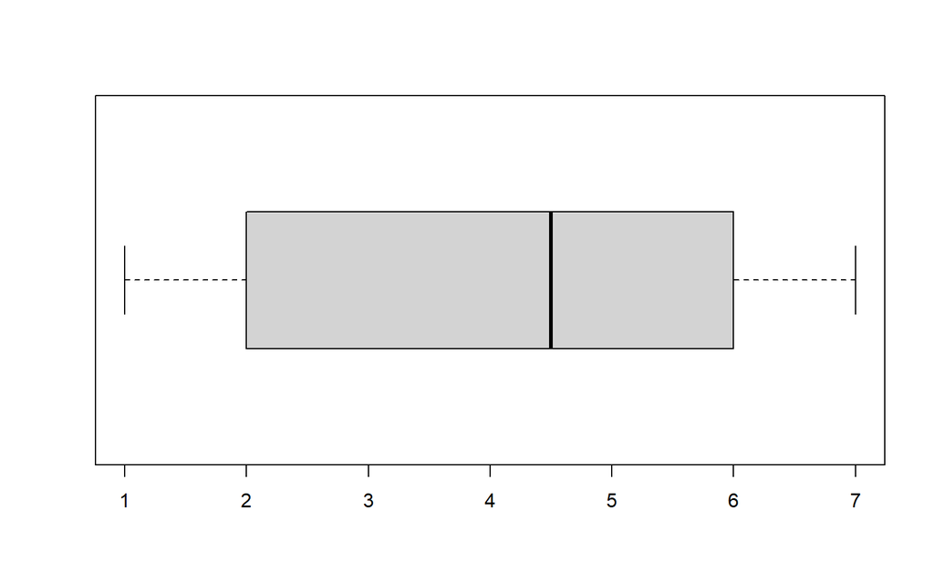

```r
boxplot(ord, horizontal=TRUE)
```

En effet, la ligne centrale représente la médiane, la bordure inférieure de la boîte représente le premier quartile, la bordure supérieur représente le troisième quartile, et les valeurs extrêmes se trouvent à chacune des extrémités du graphique.

```r
xr = plyr::mapvalues(x,from = c("Cat1","Cat2",...,"Catk"), to = c(1:k))
```

Un exemple sera donné plus loin.

#### 7.3.4.1 Différentes options pour obtenir la médiane

Sous R, on dispose très fréquemment de différentes alternatives pour arriver au même résultat. Les codes R suivants illustrent ce point en affichant quelques manières d’obtenir la médiane d’un ensemble de données (ordinales, ou quantitatives).

```r
x = sort(round(rnorm(20,50,10),2))        # Données
pos = (length(x)+1)/2                     # Position de la médiane
md = 0.5*(x[floor(pos)]+x[ceiling(pos)])  # Calcul de la médiane

# ... ou...

if((length(x)%%2)==0){                    # n pair?
  md = 0.5*(x[floor(pos)]+x[ceiling(pos)])
  } else{
    md = x[pos]}
cat("Médiane =",md)
```

```
#> Médiane = 48.695
```

Ce code détermine si le nombre de données est pair ou impair. S’il est impair, la médiane correspond au score occupent la position $(n+1)/2$; s’il est pair, elle correspond à la somme des deux scores occupant les positions *plancher* et *plafond* de $(n+1)/2$, divisée par 2.

- Alternative 1: median()

```r
# Alternative 1: fonction median()...
md = median(x)
cat("Médiane =",md)
```

```
#> Médiane = 48.695
```

La fonction **median()** retourne la médiane

- Alternative 2: summary()

```r
# Alternative 2: fonction summary()...
summary(x)
```

```
#>    Min. 1st Qu.  Median    Mean 3rd Qu.    Max.
#>   35.12   42.70   48.70   49.22   54.55   68.02
```

La fonction **summary()** retourne le minimum, le maximum, la moyenne (inutile dans le cas de données ordinales!), et les trois quartiles, dont la médiane.

- Alternative 3: quantile()

```r
# Alternative 3: fonction quantile()...
md = quantile(0.5)
cat("Médiane =",md)
```

```
#> Médiane = 0.5 0.5 0.5 0.5 0.5
```

- Alternative 4: osych::describe()

```r
round(t(psych::describe(x)),3)  # t(): transposition du tableau
```

```
#>              X1
#> vars      1.000
#> n        20.000
#> mean     49.224
#> sd        9.146
#> median   48.695
#> trimmed  48.819
#> mad       9.007
#> min      35.120
#> max      68.020
#> range    32.900
#> skew      0.408
#> kurtosis -0.843
#> se        2.045
```

La fonction **describe()** de la librairie **psych** produit une liste des principaux indices descriptifs, dont la médiane.

#### 7.3.4.2 Exercice 2

1. Utilisez la fonction **likert_7()** de la librairie **wakefield** afin de générer 500 données ordinales dont les attributs sont les 7 points suivants:
- “Parfaitement d’accord”
- “D’accord”
- “Un peu d’accord”
- “Neutre”
- “Un peu en désaccord”
- “En désaccord”
- “Parfaitement en désaccord”

Faites en sorte que les proportions des “accords” soient plus élevées que les proportions de “désaccord” Le nom de la variable générée sera: OPINION

La syntaxe générale de cette fonction est:

```r
x = likert_7(n,
             x = c("Strongly Agree", "Agree", "Somewhat Agree",
                   "Neutral", "Somewhat Disagree","Disagree",
                   "Strongly Disagree"),
             prob = c(rep(1,7)),
name = "Likert")
```

Lorsque les catégories ordonnées sont alphanumériques, il est nécessaire de les recoder pour qu’elles soient identifiées par des valeurs numériques. La fonction **mapvalues()** de la librairie **plyr** permet ce recodage. Par exemple, un code R tel que le suivant permettra d’effectuer cette opération. La fonction **as.numeric()** assure que le résultat sera numérique et approprié pour les opérations suivantes.

```r
categor = c("Strongly Agree", "Agree", "Somewhat Agree",
            "Neutral", "Somewhat Disagree","Disagree",
            "Strongly Disagree")
xrec = as.numeric(plyr::mapvalues(x, from = categor, to = c(1:7)))
```

2. Obtenez des représentations graphiques de cet ensemble de données: diagramme en barres et diagramme en boîte.
3. Calculez la médiane de cet ensemble de données (essayez plusieurs méthodes)

### 7.3.5 Mesure de dispersion: données nominales

Un indice de variation que l’on peut obtenir dans le cas d’une variable nominale est le **rapport de variation (RV)**. Il s’agit simplement du rapport entre le nombre de cas occupant la catégorie modale et le nombre de cas qui se trouvent hors de cette catégorie. Formellement,

$$RV=1-\frac{f_{mode}}{N} \tag{7.1}$$

Lorsque le mode n’est pas unique dans la distribution, RV tient compte de l’ensemble des effectifs des catégories modales (supposées égales):

$$RV=1-\frac{n_{mode}\times f_{mode}}{N} \tag{7.2}$$

La définition du rapport de variation (RV) se traduit par une probabilité, celle qu’en choisissant une observation au hasard, cette dernière n’**appartienne pas** à la catégorie modale.

Si la distribution est bi- ou multimodale, le calcul du rapport de variation impliquera la somme des fréquences de chacune des catégories modales.

Considérons à nouveau une variable telle que celle définie plus haut.

```r
set.seed(150752)  # S'assurer de reproduire les résultats
categ = c("Cat 1","Cat 2","Cat 3","Cat 4","Cat 5","Cat 6","Cat 7")
x = sample(categ,
           50,
           replace=TRUE,
           prob=c(1,2,3,4,3,2,1))
tbl = table(x)
N = sum(tbl)
tbl
```

```
#> x
#> Cat 1 Cat 2 Cat 3 Cat 4 Cat 5 Cat 6 Cat 7
#>     5     6     6    15     8     7     3
```

Le rapport de variation dans ce cas serait:

```r
mode <- DescTools::Mode(x)

if (is.na(mode[1])) {
    nomode <- 0
} else {nomode <- length(mode)}

VarRat = 1-nomode*max(tbl)/N           # Rapport de Variation
cat("Rapport de Variation = ",VarRat)
```

```
#> Rapport de Variation =  0.7
```

On interprète le rapport de variation de la manière suivante:

1. S’il n’y a pas de catégorie modale, alors la variation est maximale: RV = 1.0
2. Plus la fréquence modale est élevée, moins il y a de dispersion entre les autres catégories. À la limite, si tous les cas se trouvaient dans la catégorie modale, il n’y aurait aucune dispersion, et RV = 0.

NOTE: Cet indice n’est pas vraiment présenté dans un rapport de recherche. Il est présenté ici simplement pour illustrer que même dans le cas d’une variable nominale, les trois caractéristiques fondamentales d’un ensemble de données sont présentes!

Quelques autres mesures de dispersion pour données nominales se fondent sur les écarts des fréquences non modales par rapport à la fréquence modale. Parmi ces mesures, on retrouve:

1. Déviation Modale Moyenne (DMM):

$$DMM=1-\sum_{i = 1}^{k}\frac{{f_{mode}-f_i}}{N(k-1)} \tag{7.3}$$

2. Indice de Variation Qualitative (IVQ):

$$IVQ=\left(\frac{k}{k-1}\right)\left[1-\sum_{i = 1}^{k}p_i^2\right] \tag{7.4}$$

3. Indice d’Entropie Relative (IER):

$$IER=-\sum_{i = 1}^{k}\frac{\left[ p_i \times log(p_i)\right]} {log(k)} \tag{7.5}$$

4. Écart-Type du Mode (ETM):

$$ETM=1-\sqrt{\frac{\sum\limits_{i=1}^{k}(f_{mode}-f_i)^2}{N^2(k-1)}} \tag{7.6}$$

Pour les données nominales générées ci-dessus, on obtient:

```r
k = length(tbl)
N = sum(tbl)
xs = sort(tbl,descending=FALSE)
DMM = 1-(sum(xs[k]-xs[1:k-1]))/(N*(k-1))
cat("DMM = ",DMM)
```

```
#> DMM =  0.8166667
```

```r
IVQ = (k/(k-1))*(1-sum((tbl/N)**2))
cat("IQV = ",IVQ)
```

```
#> IQV =  0.9594667
```

```r
IER = -sum((tbl/sum(tbl))*log(tbl/sum(tbl)))/log(k)
cat("IER = ",IER)
```

```
#> IER =  0.944333
```

```r
ETM = 1-sqrt(1/((k-1)*N^2)*sum((xs[k]-xs)^2))
cat("ETM = ",ETM)
```

```
#> ETM =  0.8139892
```

En sélectionnant une observation au hasard, le rapport de variation indique qu’on a 70% des chances d’obtenir une donnée ne provenant pas de la catégorie modale: une grande proportion des données se répartissent dans les autres catégories. Cette grande dispersion est confirmée par les indices fondés sur les écarts par rapport au mode, pour lesquels on obtient des valeurs se rapprochant de 1.0.

Pour fins de comparaison, considérons des ensembles de données de niveaux de dispersion très élevés et très faibles.

#### 7.3.5.1 Dispersion élevée (distribution presque uniforme)

Lorsqu’une distribution tend vers l’uniformité, la dispersion est élevée. Le code R suivant illustre cette situation:

```r
x=c(rep("Cat 1",8),rep("Cat 2",8),rep("Cat 3",8),
    rep("Cat 4",9),  rep("Cat 5",8),rep("Cat 6",8),
    rep("Cat 7",8))

tbl = table(x)
N = sum(tbl)
tbl
```

```
#> x
#> Cat 1 Cat 2 Cat 3 Cat 4 Cat 5 Cat 6 Cat 7
#>     8     8     8     9     8     8     8
```

Dans un tel cas, on calcule:

```r
mode = Mode(x)

VarRat = 1-length(mode)*max(tbl)/N           # Rapport de Variation
cat("Rapport de Variation = ", VarRat)
```

```
#> Rapport de Variation =  0.8421053
```

```r
k = length(tbl)
N = sum(tbl)
xs = sort(tbl,descending=FALSE)
DMM = 1-(sum(xs[k]-xs[1:k-1]))/(N*(k-1))
cat("DMM = ", DMM)
```

```
#> DMM =  0.9824561
```

```r
IVQ = (k/(k-1))*(1-sum((tbl/N)**2))
cat("IQV = ", IVQ)
```

```
#> IQV =  0.9996922
```

```r
IER = -sum((tbl/sum(tbl))*log(tbl/sum(tbl)))/log(k)
cat("IER = ", IER)
```

```
#> IER =  0.9995387
```

```r
ETM = 1-sqrt(1/((k-1)*N^2)*sum((xs[k]-xs)^2))
cat("ETM = ", ETM)
```

```
#> ETM =  0.9824561
```

Le Rapport de Variation indique qu’en choisissant une observation au hasard, la probabilité que cette dernière n’appartienne pas à la catégorie modale est élevée: 0.842. On peut donc conclure à une dispersion élevée des observations: elles ne sont pas concentrées dans un petit nombre de catégories. Ce niveau de dispersion est confirmé par l’ensemble des mesures de dispersion fondées sur l’écart par rapport au mode.

#### 7.3.5.2 Dispersion ‘presque’ nulle (distribution presque constante)

Examinons un cas où un mode existe, mais les fréquences observées pour toutes les autres catégories non modales sont très faibles: la catégorie modale englobe la presque totalité des effectifs, ce qui se traduit par une dispersion presque nulle:

```r
# Unimodale, dispersion 'presque' nulle
x=c(rep("Cat 1",1),rep("Cat 2",1),rep("Cat 3",1),
    rep("Cat 4",40),  rep("Cat 5",1),rep("Cat 6",1),
    rep("Cat 7",1))
tbl = table(x)
N = sum(tbl)
tbl
```

```
#> x
#> Cat 1 Cat 2 Cat 3 Cat 4 Cat 5 Cat 6 Cat 7
#>     1     1     1    40     1     1     1
```

```r
mode = Mode(x)            # Détermination du/des mode(s)

VarRat = 1-length(mode)*max(tbl)/N           # Rapport de Variation
cat("Rapport de Variation = ", VarRat)
```

```
#> Rapport de Variation =  0.1304348
```

```r
k = length(tbl)
N = sum(tbl)
xs = sort(tbl,descending=FALSE)
DMM = 1-(sum(xs[k]-xs[1:k-1]))/(N*(k-1))
cat("DMM = ", DMM)
```

```
#> DMM =  0.1521739
```

```r
IVQ = (k/(k-1))*(1-sum((tbl/N)**2))
cat("IQV = ", IVQ)
```

```
#> IQV =  0.2811909
```

```r
IER = -sum((tbl/sum(tbl))*log(tbl/sum(tbl)))/log(k)
cat("IER = ", IER)
```

```
#> IER =  0.3190898
```

```r
ETM = 1-sqrt(1/((k-1)*N^2)*sum((xs[k]-xs)^2))
cat("ETM = ", ETM)
```

```
#> ETM =  0.1521739
```

Le rapport de variation indique que la probabilité, en sélectionnant une observation au hasard, d’obtenir une donnée qui ne se trouve pas dans la catégorie modale est faible: 0.13. Les autres indices de dispersion confirment un niveau de dispersion très faible.

#### 7.3.5.3 Librairie **qualvar** (Optionnel)

La librairie **qualvar** offre plusieurs fonctions permettant de quantifier la variation dans les variables qualitatives, incluant la Déviation Modale Moyenne (DMM), et l’Indice d’Entropie Relative (IER ou *HREL*). D’autres sont disponibles, et sont mentionnées ci-dessous par souci d’une présentation exhaustive des indices qui pourraient être utiles dans différents contextes. On pourra consulter la [documentation de cette librairie](https://cran.r-project.org/web/packages/qualvar/index.html) pour les détails. En plus des indices présentés dans les paragraphes précédents, on note:

- Déviation Analogue Moyenne (*ADA*):

$$ADA=1-\sum\limits_{i=1}^{k}{\frac{\left|f_i-\frac{n}{k}\right| }{2\left[\frac{n}{k}(k-1)\right] }} \tag{7.7}$$

- B (Moyenne géométrique modifiée):

$$B=\sqrt{1-\left(\sqrt[k]{\prod\limits_{i=1}^{k}{\frac{f_ik}{n}} } \right)^2 } \tag{7.8}$$

- MDA (Différence moyenne analogue):

$$MDA=1-\sum\limits_{i=1}^{k-1}{\sum\limits_{j=i+1}^{k}{\frac{\left|f_i-f_j\right| }{n(k-1)}}} \tag{7.9}$$

- VA (Variance Analogue):

$$VA=1-\sum\limits_{i=1}^{k}{\frac{\left(f_i-\frac{n}{k}\right)^2 }{\frac{n^2(k-1)}{k}}} \tag{7.10}$$

#### 7.3.5.4 Exercice 3

1. Reprenez la variable EMPLOI générée antérieurement:

```r
n = 500
x = employment(n,x = c("Plein Temps", "Temps Partiel",
                       "Sans Emploi", "Retraite", "Etude"),
               prob = c(0.5, 0.15, 0.1, 0.15, 0.1),
               name = "Variable")
```

2. Examinez les indices de dispersion pour cette variable nominale. Comment qualifieriez-vous cette distribution? (NOTE: la librairie **DescTools** est nécessaire ici!)

### 7.3.6 Mesure de dispersion: données ordinales

#### 7.3.6.1 Mesures fondées sur les fractiles

Dans le cas de données ordinales (les catégories d’une variable sont ordonnées), l’**écart inter-quartile** (EIQ) est un indicateur du degré de dispersion. Cet indice n’est que la différence entre le troisième et le premier quartile d’une distribution. On l’obtient en utilisant la fonction **IQR()**:

```r
IQR(ord)
```

```
#> [1] 4
```

ou en utilisant la fonction **quantile()**, ou la fonction **summary()**:

```r
cat("EIQ = ", quantile(ord,0.75)-quantile(ord,0.25))
```

```
#> EIQ =  4
```

```r
st <- summary(ord)
st
```

```
#>    Min. 1st Qu.  Median    Mean 3rd Qu.    Max.
#>    1.00    2.00    4.50    4.26    6.00    7.00
```

```r
cat("EIQ = ",summary(ord)[5]-summary(ord)[2])
```

```
#> EIQ =  4
```

Essentiellement, cet indice correspond à l’étendue des 50% centraux de la distribution.

Il est également possible d’obtenir des indices de dispersion fondés sur d’autres fractiles. Par exemple, on pourrait calculer l’écart inter-décile, en évaluant la distance séparant le premier décile du neuvième; ou celle séparant le 2e décile du 8e:

```r
deciles <- quantile(ord, c(0.1,0.2,0.8,0.9))
cat("Écart Inter-Déciles (d9-d1)",deciles[4]-deciles[1])
```

```
#> Écart Inter-Déciles (d9-d1) 5
```

```r
cat("Écart Inter-Déciles (d8-d2)",deciles[3]-deciles[2])
```

```
#> Écart Inter-Déciles (d8-d2) 4
```

Ces options seraient aussi défendables que l’écart inter-quartile, qui demeure malgré tout plus souvent utilisé.

#### 7.3.6.2 Mesure du consensus (ou de dissension)

Un angle sous lequel on peut examiner la dispersion d’une variable ordinale consiste à considérer le degré de consensus se traduisant par des fréquences élevées dans une catégorie particulière. On pourrait également considérer le degré de dissension se traduisant par des fréquences élevées dans les catégories opposées. Cette conceptualisation n’est pas très éloignée de ce qui a été fait dans le cas de variables nominales dans la section précédente. Mais étant donné que les attributs de la variable sont ordonnés, on a avantage à tenir compte des informations portées par cet ordre.

Une variable obtenue à l’aide d’une échelle de Likert représente un exemple idéal pour illustrer la procédure. Une échelle de Likert est très souvent utilisée dans les questionnaires, dans un contexte de sondage, par exemple. Les attributs des variables qui en résultent sont de nature ordinale. Par exemple, à une question telle que : “Concernant le projet de loi XYZ, je suis…”, on offre les choix de réponse suivants:

```
1 = Très défavorable
2 = Défavorable
3 = Neutre
4 = Favorable
5 = Très favorable
```

Si une très grande majorité des répondants optent pour les choix 4 et 5, on dira que le degré de consensus est élevé. Sinon, si les réponses se répartissent à peu près également dans toutes les catégories, on pourra conclure que le degré de consensus est faible. Si les deux extrémités de l’échelle présentent des fréquences élevées, on pourra parler de dissension. L’objectif, ici, est de quantifier le consensus.

Une mesure développée à cette fin (Tastle & Wierman, 2007) est définie par l’équation suivante:

$$\begin{eqnarray}
Cns(x)&=&1+\sum\limits_{i=1}^{k}p_i log_2 \left(1-\frac{\left| f_i-\mu_x\right|}{d_x}\right) \\ d_x&=&X_{max}-X_{min} \\
\mu_x&=&\sum\limits_{i=1}^{k}p_iX_i
\end{eqnarray}$$

Cns(x) prend une valeur comprise entre 0, lorsque les données se répartissent également dans les deux extrémités (dissension), et 1, lorsque toutes les réponses se trouvent dans une catégorie particulière (consensus). Si les données se répartissent également dans les différentes catégories, Cns(x) est approximativement égal à 0.5. Le code R suivant simule une telle variable et en calcule le degré de consensus:

```r
set.seed(150752)
categ <- 1:5         # Échelle ordinale, 5 points
x <- sample(categ,80,replace=TRUE)
tbl <- table(x)
tbl
```

```
#> x
#>  1  2  3  4  5
#> 16 14 18 17 15
```

```r
prop  <- tbl/sum(tbl)  # Proportions de réponses dans chaque catégorie
mu <- sum(categ * prop)# 'Moyenne' de la distribution
tbl
```

```
#> x
#>  1  2  3  4  5
#> 16 14 18 17 15
```

```r
cns <- 1 + sum(prop*log2(1-(abs(categ - mu) / (max(categ)-min(categ)))))
cat("Consensus = ",cns)
```

```
#> Consensus =  0.4507539
```

Se rapprochant de 0.5, ce résultat indique un niveau de consensus faible.

La fonction **consensus()** de la librairie **agrmt** permet également ce calcul. Son argument est le vecteur des fréquences observées dans chacune des catégories ordonnées:

```r
agrmt::consensus(table(x))
```

```
#> [1] 0.4507539
```

Lorsqu’il y a consensus, une grande majorité des réponses se trouvent dans une catégorie particulière, et on obtient, par exemple:

```r
fx = c(1,1,20,1,1)
consensus(fx)
```

```
#> [1] 0.8820802
```

Lorsque le consensus est ‘parfait’, on obtient:

```r
fx = c(0,0,20,0,0)
consensus(fx)
```

```
#> [1] 1
```

Il y a également consensus lorsque les catégories contenant une forte proportion des réponses sont adjacentes l’une à l’autre:

```r
fx = c(0,0,0,20,20)
consensus(fx)
```

```
#> [1] 0.8073549
```

Mais lorsque les réponses se concentrent dans les deux extrémités de l’échelle, on obtient:

```r
fx = c(20,0,0,0,20)
consensus(fx)
```

```
#> [1] 0
```

Le consensus est donc une mesure sensible aux polarisations. Dans ce dernier cas, on pourra parler de ‘dissension’.

#### 7.3.6.3 Exercice 4

1. Reprenez la variable **ord** générée antérieurement:

```r
library(wakefield)
ord = r_sample_ordered(n=50, c(1:7),
                       prob = NULL,
                       name = "Réponse")
ord = as.numeric(ord)
```

2. Obtenez un diagramme en barres pour cette variable. Quelle est votre perception initiale concernant la dispersion de cette variable?
3. Obtenez un diagramme en boîte pour ces données. Votre appréciation de la dispersion change-t-elle?
4. Calculez l’intervalle inter-quartile et prenez-en note pour les exercices suivants.
5. Obtenez la mesure de consensus pour cette variable, et qualifiez la dispersion à partir du résultat obtenu. Prenez-en note pour les exercices suivants.
6. Générez une nouvelle variable ordinale en utilisant le même processus générateur, mais en altérant les probabilités associées à chaque attribut possible:

```r
ord = wakefield::r_sample_ordered(n=50, c(1:7),
                                  prob = c(10,8,2,0,2,8,10),
                                  name = "Réponse")
ord = as.numeric(ord)
```

1. Obtenez la médiane de cette variable
2. Calculez l’écart inter-quartile pour ces données
3. Obtenez un diagramme en barres pour cette variable
4. Quelle est votre perception de la dispersion de cette variable?
5. Obtenez la mesure de consensus pour cette variable, et qualifiez la dispersion à partir du résultat obtenu.
7. Générez une nouvelle variable ordinale en utilisant le même processus générateur, mais en altérant les probabilités associées à chaque attribut possible:

```r
ord = wakefield::r_sample_ordered(n=50, c(1:7),
                                  prob = c(1,0,1,0,4,8,10),
                                  name = "Réponse")
ord = as.numeric(ord)
```

1. Obtenez la médiane de cette variable
2. Calculez l’écart inter-quartile pour ces données
3. Obtenez un diagramme en barres pour cette variable
4. Obtenez un diagramme en boîte pour cette variable
5. Quelle est votre perception de la dispersion de cette variable?
6. Obtenez la mesure de consensus pour cette variable, et qualifiez la dispersion à partir du résultat obtenu.
8. Faites l’expérience de différentes distributions en modifiant, dans le code R utilisé ci-dessus, les probabilités des différents attributs. Le vecteur définissant **prob=** correspond aux poids accordés aux attributs 1 à 7. Les probabilités sont simplement les poids relatifs: **prob/sum(prob)**. Expérimentez différentes configurations pour apprécier le fonctionnement de l’indice de consensus. Comparez les intervalles inter-quartiles obtenus dans chaque cas, avec celui obtenu en (4). Comparez de la même manière les indices de consensus.

## 7.4 Variables quantitatives

Dans le cas d’une variable quantitative, les attributs sont non seulement ordonnés, mais l’intervalle qui les sépare est constant et connu. Par exemple, l’année de la naissance d’un individu représente une période de temps couvrant 365 jours (oublions les années bissextiles pour l’instant!), une période fixe, connue. La distance qui sépare deux individus de 20 et 25 ans est la même que la distance qui sépare des individus de 65 et 70 ans. Par contre, deux situations se présentent:

1. La valeur nulle (‘0’) est un attribut comme toutes les autres valeurs que peut prendre une variable, mais n’indique pas l’absence de cet attribut. L’An 0 dans l’histoire de l’Humanité n’indique pas le début des temps! Une température de 0 degré Celsius n’indique pas l’absence de température! On dira de cette situation qu’il n’y a pas de zéro absolu. Les variables de ce type sont dites d’**intervalle**.
2. La valeur nulle (‘0’) est absolue et indique l’absence de l’attribut. S’il n’a pas plu au cours du mois de juin au Cap-Haïtien, le nombre de millimètres de pluie est égal à 0. Une valeur négative n’est pas possible. Si une balance indique un poids nul, c’est qu’il n’y a rien sur le plateau de cette balance. Dans ce cas, on dira d’une telle variable qu’elle est **de rapport**.

Dans ces deux cas, les données peuvent être discrètes ou continues, et un très grand nombre de valeurs sont généralement possibles, en pratique ou en théorie. Dans plusieurs cas, le nombre de valeurs qu’il est possible d’observer pour ce type de variables est infini. Un calcul de probabilités tel que présenté dans les chapitres précédents ne serait donc difficilement, ou pas applicable.

### 7.4.1 Génération de données

Sous R, plusieurs fonctions permettent la génération de données aléatoires. Quelques-unes ont déjà été présentées dans le chapitre 2: **rbinom()**, **rpoisson()**, etc. Nous en utiliserons maintenant quelques-unes pour illustrer les procédures descriptives que l’on peut appliquer sur un ensemble de données quantitatives.

#### 7.4.1.1 Distribution Uniforme

Dans une distribution uniforme, les valeurs comprises entre un minimum et un maximum sont équiprobables: à la limite, lorsqu’un nombre infini de valeurs sont tirées d’une telle distribution, la distribution prend une forme rectangulaire.

Sous R, la fonction **runif()** permet de générer des données aléatoires provenant d’une distribution de ce type. Un seul argument est requis: le nombre de données à générer. Pour spécifier une valeur minimale et une valeur maximale, les deux derniers arguments sont disponibles. Par défaut, les données générées sont comprises entre 0 et 1:

```r
n = 5000
linf = 10
lsup = 20
x = runif(n,linf,lsup)
head(x,10)
```

```
#>  [1] 11.57811 12.03586 15.11744 15.47890 13.96404 13.99709 18.51332 16.59778
#>  [9] 11.87051 15.34009
```

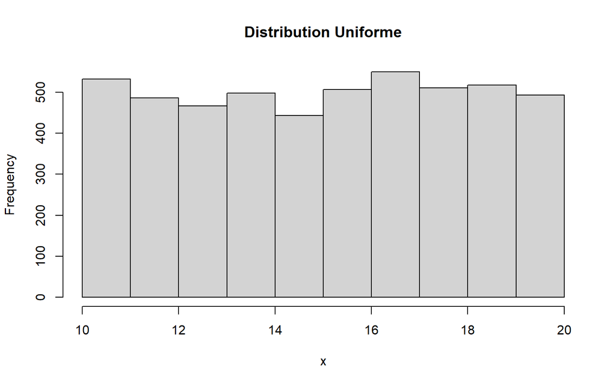

```r
hist(x,
     main="Distribution Uniforme")
```

#### 7.4.1.2 Distribution gaussienne

En Sciences, il est fréquent de rencontrer des données quantitatives dont la distribution prend une forme rappelant une cloche. Plusieurs exemples suivront dans la suite de nos présentations. Des données de ce type peuvent être générées à l’aide de la fonction **rnorm()**, qui nécessite au moins un argument: le nombre de données à générer. Si aucun autre argument n’est fourni, le centre de la distribution (sa moyenne) se trouvera aux environs de **0**, et son indice de dispersion (son écart-type) avoisinera **1.0**. Pour spécifier d’autres combinaisons de moyenne et d’écart-type il suffit de spécifier ces arguments. On obtient alors:

```r
n = 5000
moyenne = 100
ecart.type = 15
x = rnorm(n,
          moyenne,
          ecart.type)
head(round(x, 3),10)
```

```
#>  [1]  88.508  90.371 114.042  97.947  97.275 112.039  97.182 114.971 112.363
#> [10] 100.094
```

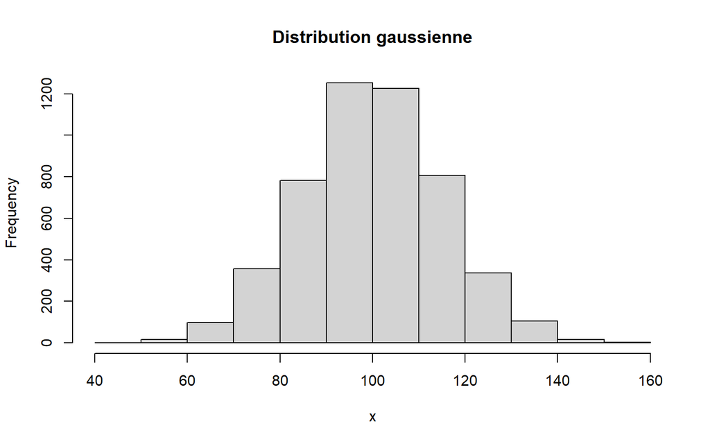

```r
hist(x,main="Distribution gaussienne")
```

Le résultat est une variable quantitative mesurée sur 5000 sujets. La moyenne arithmétique de cette variable se situe autour de 100, et son écart-type se trouve autour de 15.

#### 7.4.1.3 Distribution Exponentielle

Il semble que la durée d’un appel au Service à la Clientèle de Apple est d’en moyenne, 17 minutes. On note également qu’un très grand nombre d’appels ont une durée inférieure à 17 minutes et très peu ont des durées supérieures. Ce type d’observations suit souvent la distribution exponentielle.

```r
x = rexp(5000,0.0588)
head(x)
```

```
#> [1]  8.6240401  0.5189356  2.6214212 17.6551139  2.5903956  6.2330276
```

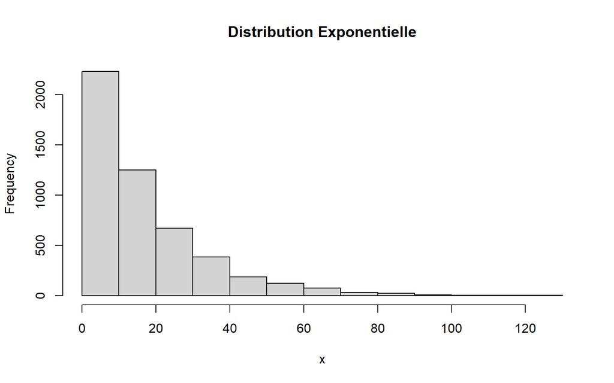

```r
hist(x,
     main="Distribution Exponentielle")
```

### 7.4.2 Données quantitatives: Forme de la distribution

La forme d’une distribution est probablement la première caractéristique que l’on saisit en examinant un diagramme résumant un ensemble de données. Dans une analyse descriptive de données, différents types de graphiques et/ou des tableaux de fréquences sont généralement efficaces pour nous permettre de qualifier cette forme.

#### 7.4.2.1 Tableaux de fréquences

Un premier exercice qu’il est généralement utile de compléter sur un ensemble de données consiste à condenser, ou organiser les données de manière à pouvoir en déceler les principales caractéristiques. Lorsque les données sont de nature quantitatives, on doit fréquemment les regrouper dans des intervalles de classe. Cette opération implique nécessairement une perte d’information dont l’ampleur est inversement proportionnelle au nombre de classes utilisées. Plusieurs ‘règles’ permettent de déterminer ce nombre, pour que l’efficacité de la représentation soit maximale. Une telle règle, due à Freedman & Diaconis (1981) propose:

De cette formulation, on constate que le nombre de classes doit tenir compte de l’étendue de la variable [max(x)-min(x), et écart inter-quartile], et du nombre d’observations. La fonction **n_classes()** (Listing 7.3) effectue cette opération. Son unique argument est la variable que l’on veut examiner:

```r
n_classes(rnorm(1000, 100, 15))
```

```
#> [1] 20
```

La fonction **hist()** permet également l’argument **breaks=“FD”** pour accomplir cette tâche.

Plusieurs méthodes alternatives ont été proposées pour déterminer le nombre optimal de classes. On trouvera une discussion intéressante à ce sujet sur Wikipedia, au lien suivant: [Calcul de N_Classes](https://en.wikipedia.org/wiki/Histogram#Number_of_bins_and_width).

La fonction **TblFreq()** (Listing 7.1) permet de produire un tableau de fréquence en regroupant des observations en intervalles de classe. Par la suite, les fréquences absolues, relatives, cumulatives, et cumulatives-relatives sont reproduites. La variable contenant les données est le seul argument qu’il est nécessaire d’utiliser. Un second argument (**bins**) permet de spécifier le nombre approximatif d’intervalles composant la distribution. Par défaut, ce nombre est 20. La Figure 7.4 et la Table 7.1 (16 premières classes) illustrent l’application de cette fonction sur les données générées à la section Section 7.4.1.3.

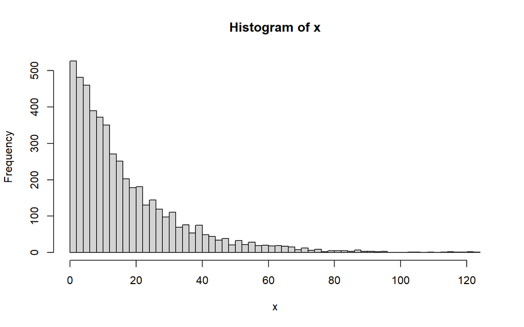

Figure 7.4

```r
TF <-  TblFreq(x, bins=n_classes(x))
```

```r
TF[1:16, ] %>%
  kbl(caption="Tableau de Fréquences", digits=3) %>%
  kable_styling(bootstrap_options = c("striped", "hover", "condensed"),
                full_width=FALSE)
```

Table 7.1: Tableau de Fréquences

| LimInf | LimSup | FreqAbs | FreqRel | FreqCum | FreqRelCum |
| --- | --- | --- | --- | --- | --- |
| -0.5 | 1.5 | 526 | 0.105 | 526 | 0.105 |
| 1.5 | 3.5 | 481 | 0.096 | 1007 | 0.201 |
| 3.5 | 5.5 | 460 | 0.092 | 1467 | 0.293 |
| 5.5 | 7.5 | 390 | 0.078 | 1857 | 0.371 |
| 7.5 | 9.5 | 372 | 0.074 | 2229 | 0.446 |
| 9.5 | 11.5 | 350 | 0.070 | 2579 | 0.516 |
| 11.5 | 13.5 | 271 | 0.054 | 2850 | 0.570 |
| 13.5 | 15.5 | 251 | 0.050 | 3101 | 0.620 |
| 15.5 | 17.5 | 202 | 0.040 | 3303 | 0.661 |
| 17.5 | 19.5 | 178 | 0.036 | 3481 | 0.696 |
| 19.5 | 21.5 | 181 | 0.036 | 3662 | 0.732 |
| 21.5 | 23.5 | 130 | 0.026 | 3792 | 0.758 |
| 23.5 | 25.5 | 144 | 0.029 | 3936 | 0.787 |
| 25.5 | 27.5 | 119 | 0.024 | 4055 | 0.811 |
| 27.5 | 29.5 | 98 | 0.020 | 4153 | 0.831 |
| 29.5 | 31.5 | 111 | 0.022 | 4264 | 0.853 |

Dans un premier temps, on obtient un histogramme représentant la distribution des données. On peut ainsi visualiser le centre, la dispersion, et la forme de cette distribution.

Le tableau qui fait suite à l’histogramme présente les limites inférieures et supérieures exactes des intervalles de classe. Dans le cas présent, le nombre d’intervalles n’est pas nécessairement 20, valeur qui est implicite dans la commande. Ceci est dû au fait que nous voulons des limites entières, ce qui facilite la lecture. La fonction ajuste le nombre d’intervalles de manière à ce que cette contrainte soit respectée. Pour chacun des intervalles, les quatre colonnes de droite reproduisent les fréquences absolues, les fréquences relatives, puis cumulatives et cumulatives-relatives.

La fonction **TblFreq2()** (Listing 7.2) reprend la fonction TblFreq() (Listing 7.1) en y ajoutant différents types de représentation graphique, incluant un polygone de fréquence et une ogive:

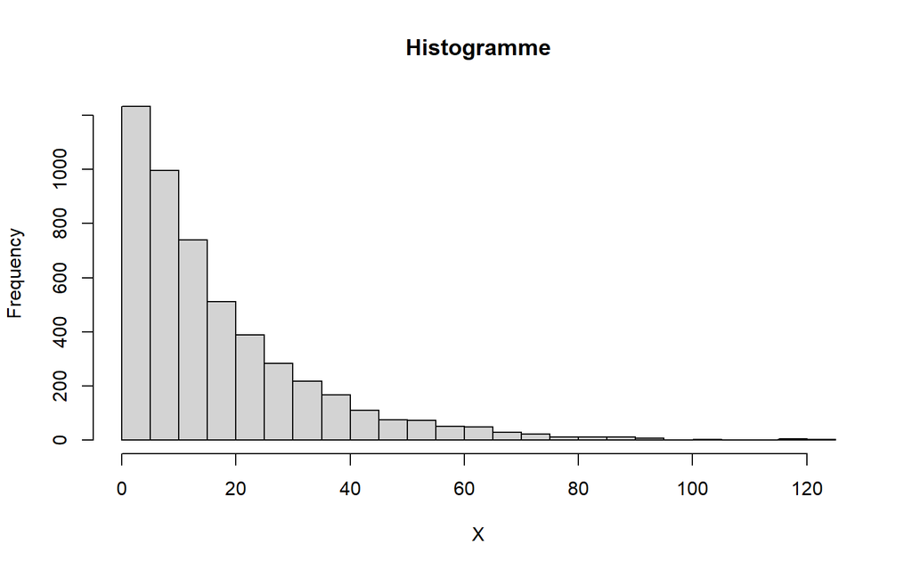

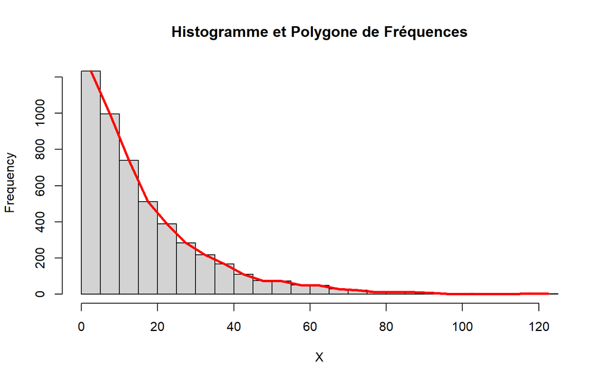

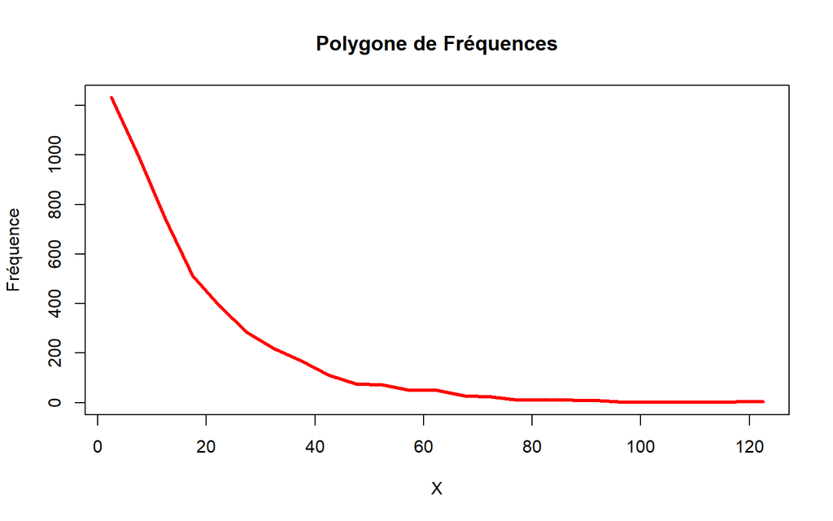

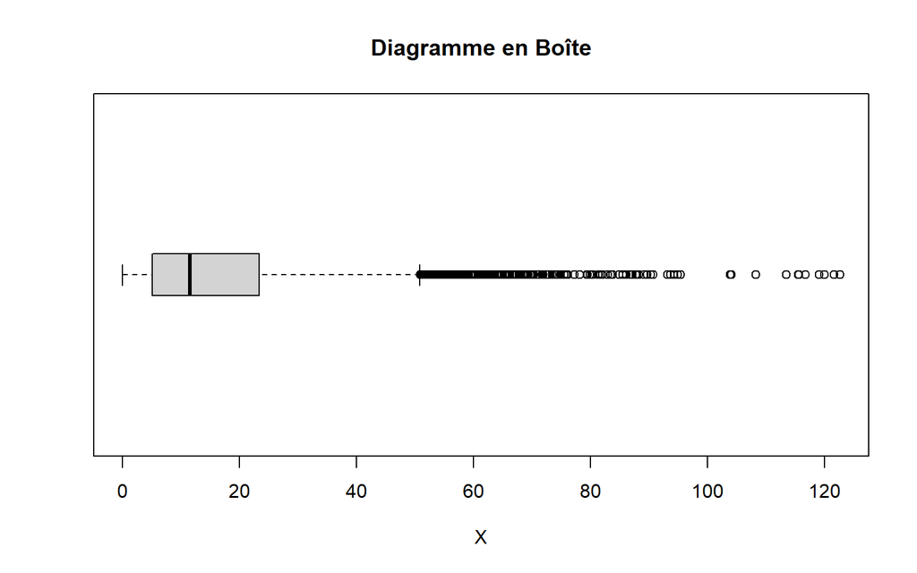

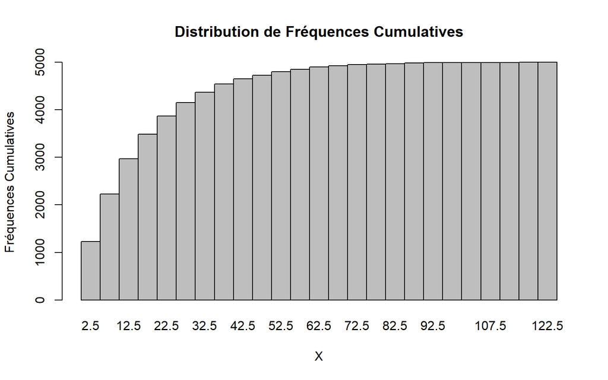

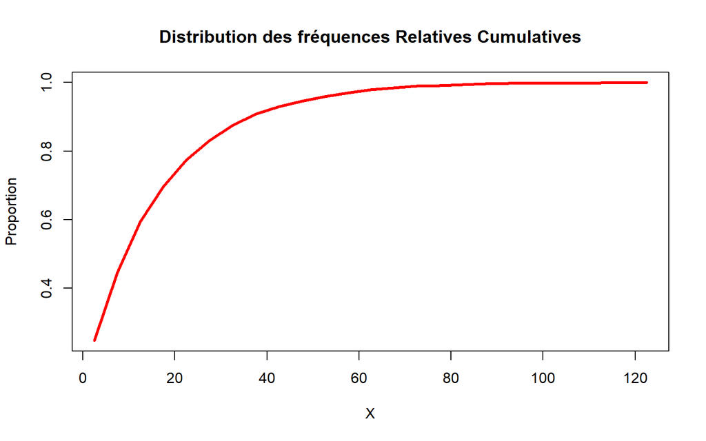

```r
TF = TblFreq2(x)
```

```r
TF[1:16, ] %>%
  kbl(caption="Tableau de Fréquences", digits=3) %>%
  kable_styling(bootstrap_options = c("striped", "hover", "condensed"),
                full_width=FALSE)
```

Tableau de Fréquences

| LimInf | LimSup | FreqAbs | FreqRel | FreqCum | FreqRelCum |
| --- | --- | --- | --- | --- | --- |
| -0.5 | 4.5 | 1232 | 0.246 | 1232 | 0.246 |
| 4.5 | 9.5 | 997 | 0.199 | 2229 | 0.446 |
| 9.5 | 14.5 | 740 | 0.148 | 2969 | 0.594 |
| 14.5 | 19.5 | 512 | 0.102 | 3481 | 0.696 |
| 19.5 | 24.5 | 389 | 0.078 | 3870 | 0.774 |
| 24.5 | 29.5 | 283 | 0.057 | 4153 | 0.831 |
| 29.5 | 34.5 | 218 | 0.044 | 4371 | 0.874 |
| 34.5 | 39.5 | 167 | 0.033 | 4538 | 0.908 |
| 39.5 | 44.5 | 111 | 0.022 | 4649 | 0.930 |
| 44.5 | 49.5 | 76 | 0.015 | 4725 | 0.945 |
| 49.5 | 54.5 | 72 | 0.014 | 4797 | 0.959 |
| 54.5 | 59.5 | 50 | 0.010 | 4847 | 0.969 |
| 59.5 | 64.5 | 49 | 0.010 | 4896 | 0.979 |
| 64.5 | 69.5 | 28 | 0.006 | 4924 | 0.985 |
| 69.5 | 74.5 | 23 | 0.005 | 4947 | 0.989 |
| 74.5 | 79.5 | 11 | 0.002 | 4958 | 0.992 |

#### 7.4.2.2 Symétrie et Voussure

L’histogramme et le polygone de fréquences nous offrent un aperçu de la forme de la distribution. Il existe cependant des indices numériques quantifiant deux aspects particuliers relatifs à cette forme: le degré de symétrie, et le degré de voussure. Ces indices font appel aux troisième (symétrie) et quatrième (voussure) moments de la distribution. On définit ainsi $Sk$ par l’équation Équation 7.11.

$$Sk=\frac{\sum\limits_{i=1}^{n}{(X_i-\bar X)^3} }{s_X^3}\times\frac{n}{(n-1)(n-2)} \tag{7.11}$$

$Sk$ prend une valeur comprise entre -3 (asymétrie négative extrême) et +3 (asymétrie positive extrême), en passant par $Sk=0$ (symétrie parfaite).

Pour sa part, l’indice de voussure ($Ku$) s’obtient à partir du quatrième moment de la distribution, et se présente sous deux formes:

- $Ku$ non-centré:

$$Ku=\frac{\sum\limits_{i=1}^{n}{(X_i-\bar X)^4} }{s_X^4} \tag{7.12}$$

Sa valeur est comprise entre 0 (distribution platykurtique) et $+\infty$ (distribution leptokurtique), en passant par $Ku=3.0$ (distribution mésokurtique).

- $Ku$ centré:

$$Ku=\frac{\sum\limits_{i=1}^{n}{(X_i-\bar X)^4} }{s_X^4}\times\frac{n(n+1)}{(n-1)(n-2)(n-3)}-\frac{3(n-1)^2}{(n-2)(n-3)} \tag{7.13}$$

Dans ce cas, $Ku$ prend une valeur comprise entre -3 et +3, suggérant une distribution platykurtique pour $(-3.0 \le Ku < 0)$, une distribution mésokurtique correspondant à $Ku=0$, et une distribution leptokurtique pour $(0 < Ku \le 3)$.

On peut obtenir ces indices à l’aide des fonctions **skewness()** et **kurtosis()** contenues dans la librairie **moments**:

```r
cat("Indice de symétrie = ", moments::skewness(x))
```

```
#> Indice de symétrie =  1.899549
```

```r
cat("Indice de voussure = ", moments::kurtosis(x))
```

```
#> Indice de voussure =  7.793973
```

Un indice de symétrie nul indique que la distribution est symétrique autour de son centre. Un indice positif indique que l’extrémité droite de la distribution est allongée, alors qu’un indice négatif indique un allongement de l’extrémité gauche. La Figure 7.5) illustre cette caractéristique.

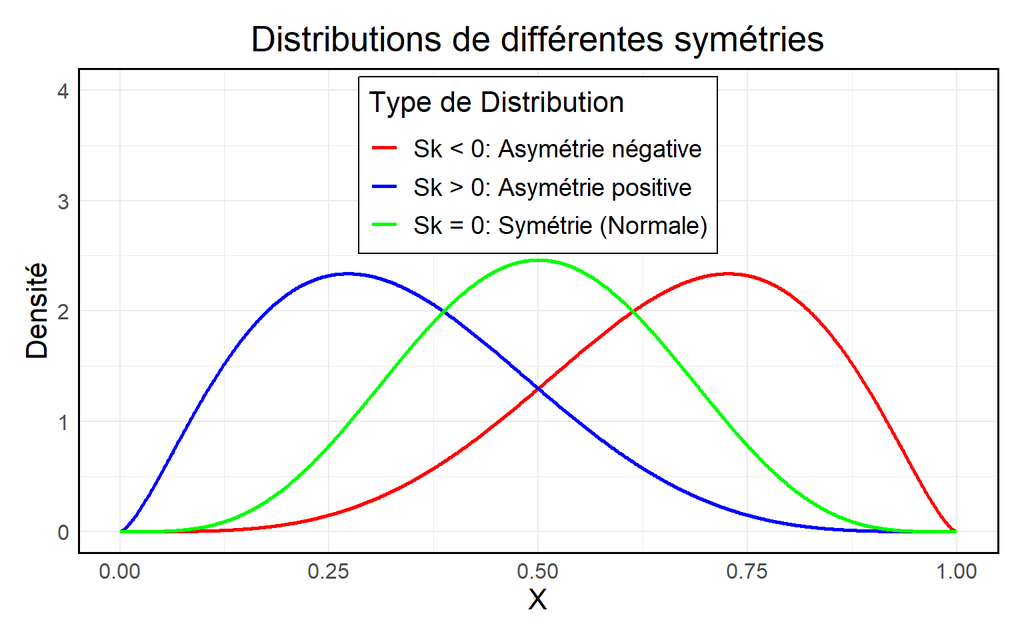

Figure 7.5: Symétrie d’une distribution

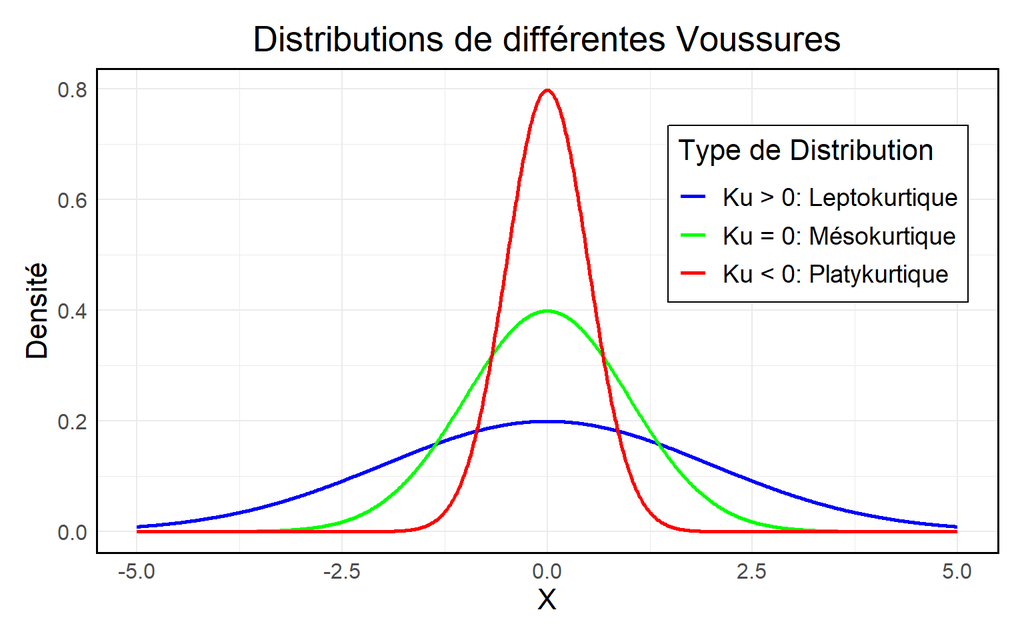

Figure 7.6: Voussure d’une distribution

Le code R suivant génère trois distributions: une asymétrique négative (Figure 7.7), une symétrique (Figure 7.8), et une asymétrique positive (Figure 7.9):

```r
x <- mnonr::unonr(10000,
                  rep(0,3),
                  diag(3),
                  skewness = c(-.7,0,.7),
                  kurtosis = c(0, 0, 0),
                  empirical = TRUE)
```

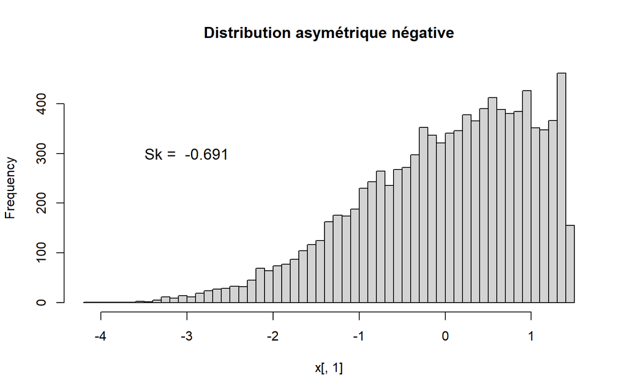

Figure 7.7: Distribution asymétrique négative

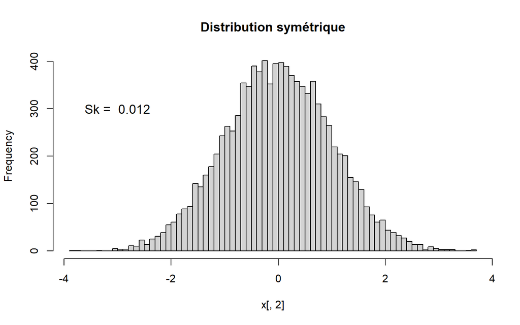

Figure 7.8: Distribution symétrique

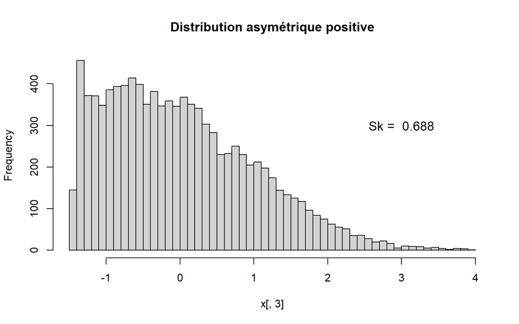

Figure 7.9: Distribution positive

Le code R suivant génère des données dont la distribution est platykurtique (Figure 7.10), mésokurtique (Figure 7.11), ou leptokurtique (Figure 7.12):

```r
x = mnonr::unonr(10000,
          rep(100,3),
          diag(3)*15,
          skewness = c(0,0,0),
          kurtosis = c(-0.8, 0, 2))
```

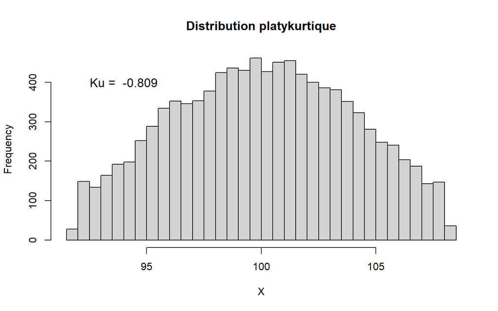

Figure 7.10: Distribution platykurtique

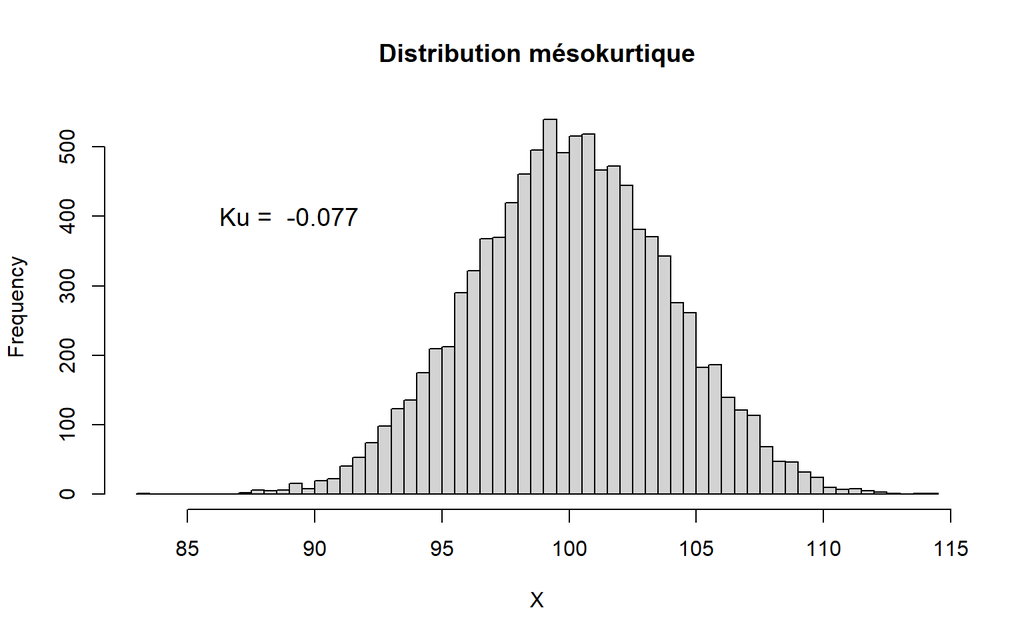

Figure 7.11: Distribution mésokurtique

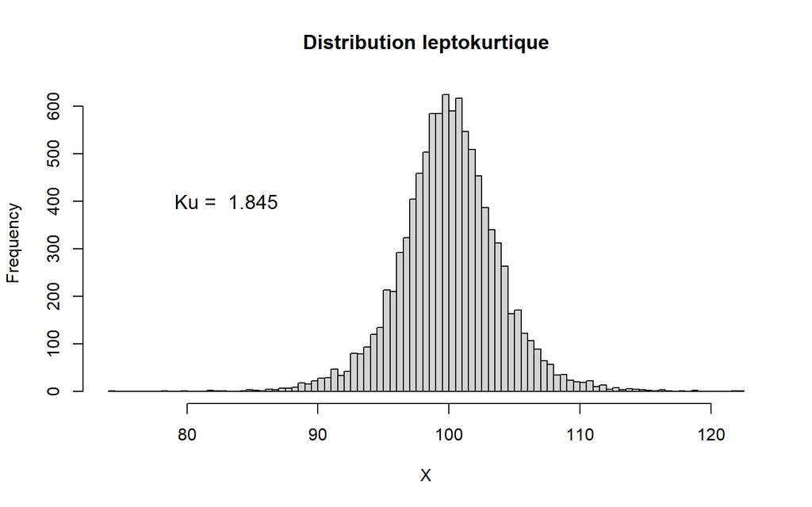

Figure 7.12: Distribution leptokurtique

#### 7.4.2.3 Courbe de densité

Pour une variable quantitative et continue, il est souvent intéressant d’afficher la distribution des densités. Il s’agit d’une évaluation de la densité de la distribution pour différents intervalles tout au long de l’étendue de la variable.

Dans une distribution continue, la probabilité d’une valeur X particulière est **toujours** nulle. En effet, le nombre de valeurs possibles que peut prendre cette variable est infini. En conséquence la probabilité d’obtenir une valeur spécifique est égale à $1/\infty=0$ . Une autre manière d’exprimer ce fait est:

$$P(X=a)=\int_{a}^{a}{f(x)} dx=0 \tag{7.14}$$

Par contre, si on considère un intervalle, aussi petit que nécessaire autour d’une valeur spécifique, la probabilité sera supérieure à 0:

$$P(X=a)=\int_{a-\delta}^{a+\delta}{f(x)} dx>0 \tag{7.15}$$

C’est ce qui définit une **densité**, que l’on peut représenter graphiquement.

Sous R, la fonction **density()** permet d’obtenir les densités correspondant à chacune des valeurs d’une distribution. Considérons les données représentées dans la Figure 7.13.

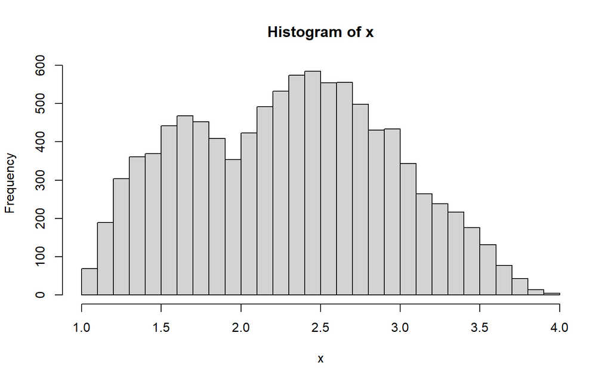

Figure 7.13: Distribution bimodale

```r
n <- 1e4
set.seed(1)
betas<-rbeta(n,2,3)
x <- c(betas[1:(n/2)]*2+1,betas[(n/2+1):n]*2+2)
hist(x, breaks="FD")
```

Les densités qu’il est possible de calculer dépendent d’une quantité appelée **bandwidth**. Plus cette quantité est petite, plus les détails de la distribution ressortiront; inversement, plus la bandwidth est grande, plus nous perdrons de détails sur la distribution. La ‘bandwidth’ est un argument de la fonction **density()**. Examinons la distribution de densité des données à la source de la Figure 7.13, représentée dans la Figure 7.14. La sortie de la fonction density() inclut chaque valeur de la variable étudiée (X), leur densité respective, et la *bandwidth* par défaut.

```r
d = density(x)
cat("Par défaut:  bw = ",d$bw)
```

```
#> Par défaut:  bw =  0.0913847
```

```r
head(cbind(d$x,d$y),15)
```

```
#>            [,1]         [,2]
#>  [1,] 0.7370653 0.0000852719
#>  [2,] 0.7438641 0.0001090758
#>  [3,] 0.7506629 0.0001385050
#>  [4,] 0.7574618 0.0001760157
#>  [5,] 0.7642606 0.0002233113
#>  [6,] 0.7710595 0.0002813428
#>  [7,] 0.7778583 0.0003520367
#>  [8,] 0.7846571 0.0004375569
#>  [9,] 0.7914560 0.0005403171
#> [10,] 0.7982548 0.0006687135
#> [11,] 0.8050536 0.0008236137
#> [12,] 0.8118525 0.0010080100
#> [13,] 0.8186513 0.0012261311
#> [14,] 0.8254502 0.0014825766
#> [15,] 0.8322490 0.0017835696
```

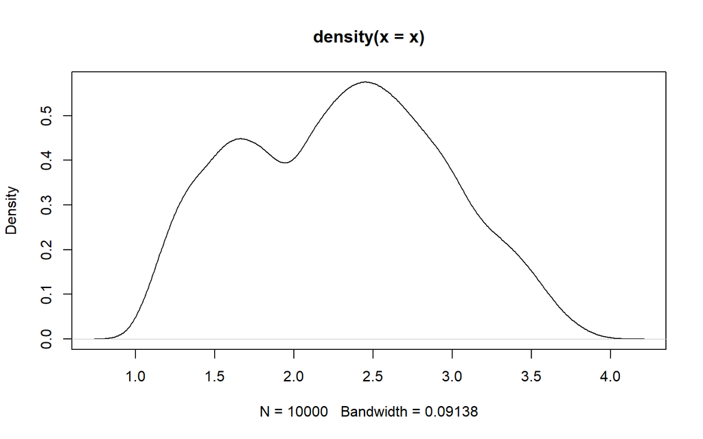

Figure 7.14: Fonction de densité

```r
plot(d)
```

En fixant bw = 0.01, on obtient la Figure 7.15.

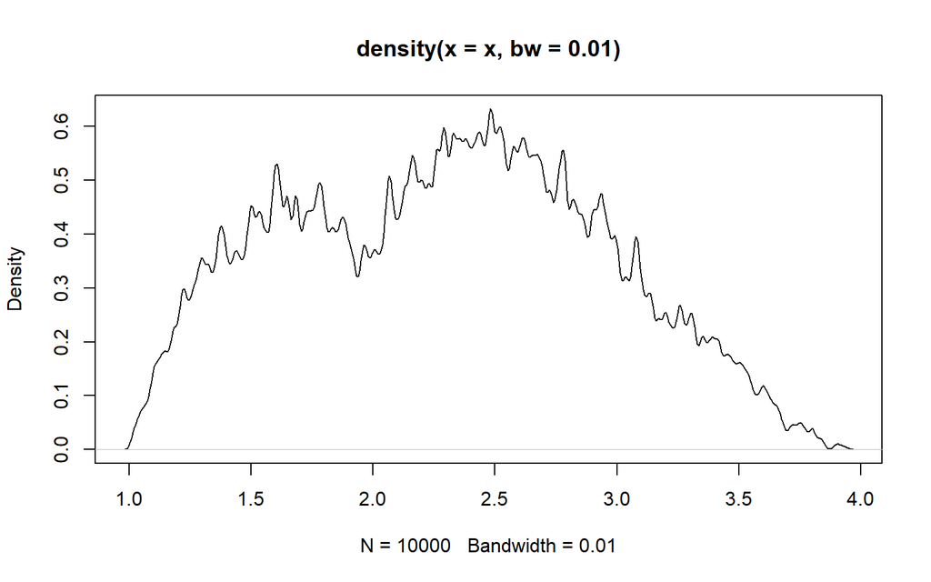

Figure 7.15: Courbe de densité (BW = 0.01)

```r
d = density(x, bw=0.01)
plot(d)
```

Et en la fixant à 0.3, on obtient la Figure 7.16.

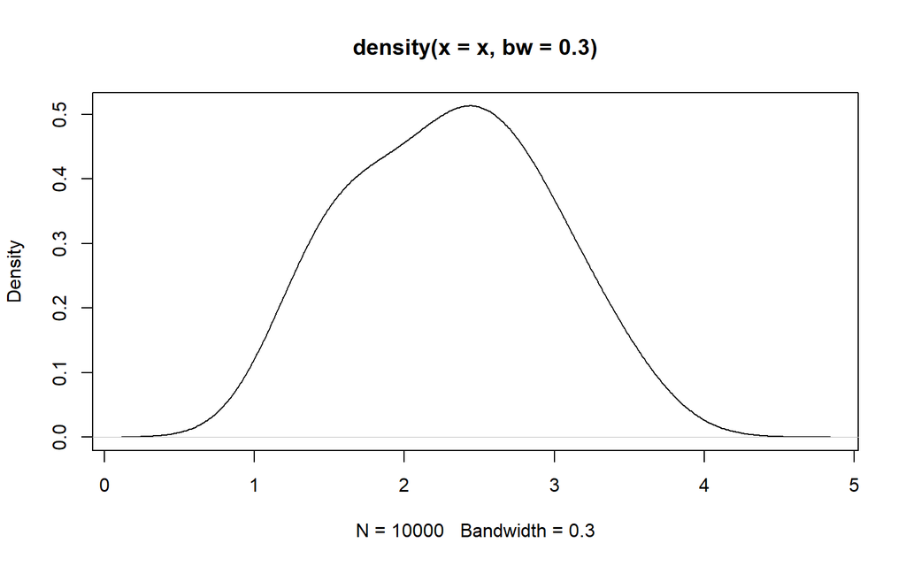

Figure 7.16: Courbe de densité (BW = 0.3)

```r
d = density(x, bw=0.3)
plot(d)
```

On constate donc que la *bandwidth* doit être sélectionnée de manière à cacher le bruit autant que possible, tout en maintenant les principales caractéristiques de la distribution. Ce serait un travail difficile, si nous ne disposions pas d’outils pour le faire. Et ces outils existent:

1. La valeur utilisée par défaut (**bw = nrd0**) est calculée en fonction des données elles-mêmes, et fonctionne bien généralement.
2. Plusieurs fonctions intégrées dans l’environnement R font l’estimation de bw. Pour les données à la source de la Figure 7.13, on obtient les valeurs suivantes:

```r
method <- c("bw.nrd",
                    "bw.nrd0",
                    "bw.ucv",
                    "bw.bcv",
                    "bw.SJ")
val <- c(bw.nrd(x),
                    bw.nrd0(x),
                    bw.ucv(x),
                    bw.bcv(x),
                    bw.SJ(x))
tbl <- data.frame("Méthode" = method, "BW" = val)
tbl %>%
  kbl(digits = 3,
      caption = "Bande passante selon la méthode de calcul") %>%
  kable_styling(bootstrap_options = c("striped", "hover", "condensed"),
                full_width=FALSE,
                latex_options = c("scale_down", "half_width"))
```

Bande passante selon la méthode de calcul

| Méthode | BW |
| --- | --- |
| bw.nrd | 0.108 |
| bw.nrd0 | 0.091 |
| bw.ucv | 0.076 |
| bw.bcv | 0.074 |
| bw.SJ | 0.075 |

Pour utiliser l’une ou l’autre de ces valeurs, il suffit d’inclure l’argument **bw=** au lancement de la fonction **density()**:

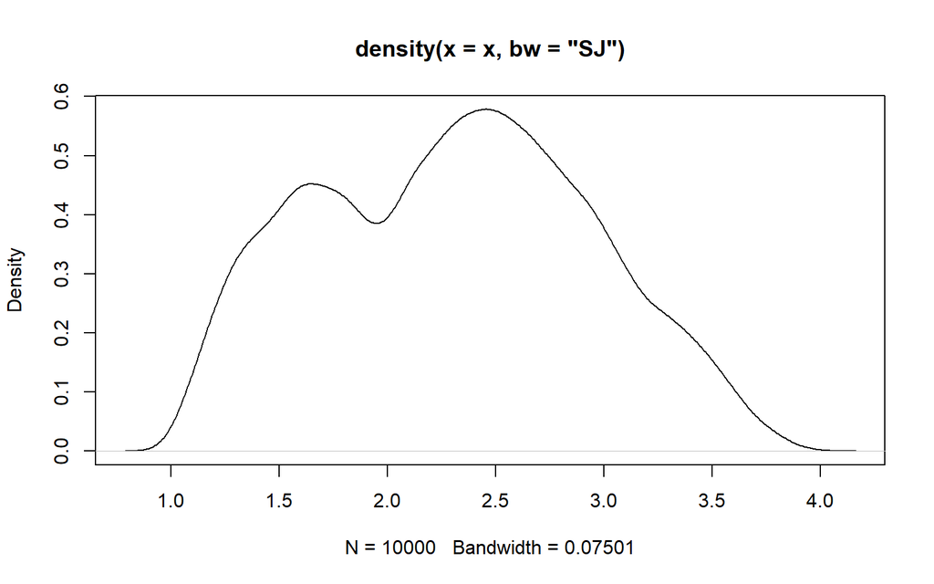

```r
d = density(x, bw="SJ")
plot(d)
```

En bref, pour nos besoins immédiats, on peut se fier à l’un ou l’autre de ces modes de sélection. Mais on conserve toujours la liberté de moduler le résultat en fonction des objectifs visés.